# Is There a Free Lunch? A Comparative Assessment of Classification Algorithms

**Yankang Li**

2018-01-30

# Overview

1. Machine Learning
2. Classification
3. Five Classification Algorithms
4. Data-sets and Methods
5. Results
6. Discussion and Outlook

## Machine Learning

How machines or computers generate knowledge from experience, without being programmed explicitly.

[figure not shown]

## Classification

**Task**:Predict a class from input features.

[figure not shown]

## Classification

**No Free Lunch Theorem**: There is no perfect algorithm for every problem, especially in the case of supervised learning.  
For general problems, the average expected performances of all algorithms are identical.  
"We have dubbed the associated results NFL theorems because they demonstrate that if an algorithm performs well on a certain class of problems then it necessarily pays for that with degraded performance on the set of all remaining problems.*" - Wolpert and Macready (1997)

## Classification

**Central Problem**: Meta-classification.  
Given the data-sets, which algorithms should we use?

## Five Classification Algorithms (1)

### *k*-Nearest-Neighbours (*k*NN)

1. There is an unlabeled data instance
2. Quantify the distance between the unlabeled data instance and labeled data instances
3. Use a majority vote from the *k* nearest labeled data to decide which category the new instance should belong to

Note: *k*NN is a lazy algorithm. It requires no training!

## Five Classification Algorithms (2)

### Support Vector Machine (SVM)

SVM constructs hyperplanes to separate the instances into different classes.  
The hyperplane with the largest margin is the best.

[figure not shown]

## Five Classification Algorithms (3)

### Decision Trees

CART: Classification And Regression Tree.  
CART splits the training set in two subsets using a single feature *k* and a threshold *t_k*. How? The tupel (*k*, *t_k*) that produces the purest subsets.  
Purity: A set is pure if it contains only a single class.

[figure not shown]

## Five Classification Algorithms (4)

### Naive Bayes

Basic assumption: each feature of the data being classified is independent of all other features given the class.

[figure not shown]

## Five Classification Algorithms (5)

### Artificial Neural Network (ANN)

[figure not shown]

## Data-sets and Methods

[figure not shown]

## Data-sets and Methods

### Tool: scikit-learn

[figure not shown]

### Tool: scikit-learn

Data is stored in a two-dimentional array with the size of *[n_samples, n_features]*.  
Every algorithm is exposed in scikit-learn via an *Estimator* object.

```python
knn = KNeighborsClassifier(n_neighbors=1)
knn.fit(X_train, y_train)
predicted = knn.predict(X_test)
print("Accuracy "+ ": "+str(np.mean(predicted == y_test)))
```

```
Accuracy : 0.7625
```

## Data-sets and Methods

### Exploratory Data Analysis (EDA)

EDA: Using summary statistics and visualization to help us better understand the data structure, so that we can make well-grounded assumptions about the data.

## Wine Quality: Correlation Graph

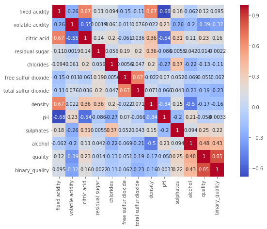

```python
plt.style.use('ggplot')
correlation_matrix = df.corr()
plt.figure(figsize=(12,6.5))
ax = sns.heatmap(correlation_matrix, vmax=1, square=True,annot=True,cmap='coolwarm')
plt.show()
```

## Data-sets and Methods

### Exploratory Data Analysis (EDA)

#### Results

*Wine Quality*:

- Some attributes have a larger range than others => **Rescaling**.

*20 Newsgroups*:

- The most frequently-used words are different among the newsgroups => **bag-of-words model**.

*Digits*:

- Principal Component Analysis (PCA) can be used to reduce dimensions.

## Data-sets and Methods

### Grid Search

*Parameters* are the coefficients found by the algorithm itself.

[figure not shown]

*Hyperparameters* controls the flexibility of the model.

### Grid Search Example

```python
def random_grid_search_knn():
    # Distribution of hyperparameter
    param_dist = {"n_neighbors": list(range(1, 31)),
                  "weights": ['uniform', 'distance'],
                  "algorithm": ['auto', 'ball_tree', 'kd_tree', 'brute'],
                  "leaf_size":list(range(15, 45)),
                  "metric":['euclidean', 'manhattan', 'chebyshev'],
                  "n_jobs": [-1, 1]
                 }
    clf = KNeighborsClassifier()
    n_iter_search = 60
    random_search = RandomizedSearchCV(clf, param_distributions=param_dist,
                                   n_iter=n_iter_search, random_state=42)
    random_grid_search_result(random_search, n_iter_search)

random_grid_search_knn()
```

```
RandomizedSearchCV took 26.94 seconds for 60 candidates parameter settings.
0.799061767005
{'weights': 'distance', 'n_neighbors': 29, 'n_jobs': -1, 'metric': 'manhattan', 'leaf_size': 15, 'algorithm': 'kd_tree'}
Accuracy  : 0.80625
```

## Results

- *k*NN performs well on the binary and image classification. It takes no training time, but a long testing time.
- SVM and Naive Bayes have triumphed over other classifiers on the text classification. Computationally not expensive.
- ANN has taken substantially more time than other classifiers. However, it has good predictive power for image classification.

## Results

To determine which classifier suits the classification task best:

1. Get to know the data and its structure through data description methods such as EDA,
2. Pre-process the data,
3. Choose several classifiers which are suitable for this kind of data,
4. Tune the hyperparameters with the help of grid search or other tools, and
5. Evaluate classifier with testing set or cross-validation.

## Discussion and Outlook

Limitations:

- "Dirty data"?
- Test Method: Training set / test set split or cross-validation?
- Bag-of-words model or word2vec?
- Tensorflow for ANN?

[figure not shown]

## Discussion and Outlook

[figure not shown]

Outlook:

- Characteristics of data-sets
- Scalability
- Parallelization
- Hyperparameter optimization

Thank you for your attention.  
Questions?